# ALK-positive Lung Cancer SC RNA-seq Workflow

- Show All Code
- Hide All Code
- View Source

Author

Ethan Littlestone

Published

July 31, 2025

## 1 Downloading Gene Expression Data

Once we know which samples we will be using, we can then download them. The gene expression matrix files (.h5 files) can be found on the [GEO Database](https://www.ncbi.nlm.nih.gov/geo/query/acc.cgi?acc=GSE274934). They can either be downloaded manually through the web, or via the *wget* command.

We can also optionally use the *pysradb* python package in order to cleanly get the GSM Ids and sample names from this experiment. We can get the corresponding SRP for our GSE using the *gse-to-srp* command, which can then be used to grab our metadata (GSM Ids and sample names).

```bash
#| eval: false
#| echo: false
pysradb gse-to-srp GSE274934
pysradb metadata SRP526658 | grep 'scRNA-seq' | cut -f 4
```

I wrote a snakemake script in order to download the .h5 files from the GEO Database.

Once we have our .h5 files, we can proceed with the analysis steps. I wrote a python script in order to read in the .h5 files as AnnData objects, and then concatenated them. Batch correction therefore must be performed.

## 2 Check if batch correction was successful (no batch effects)

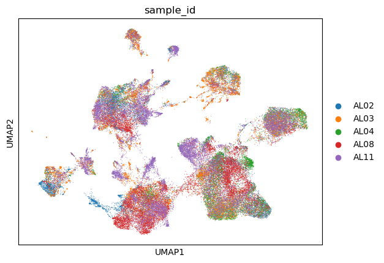

## 3 UMAP of Leiden Clusters

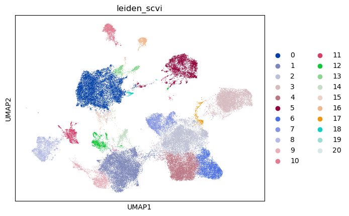

## 4 UMAP of Annotated Cell-types with CellTypist

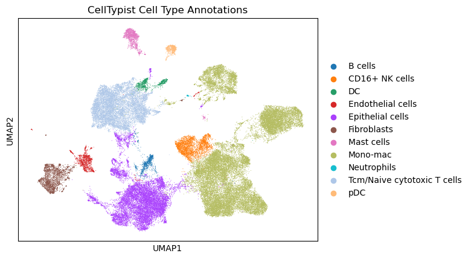

## 5 Dotplot of top DEGs per Celltype

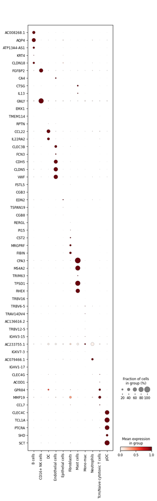

```python
import pandas as pd
pd.set_option("display.max_rows", None)
df = pd.read_csv("../../results/GSE274934/csvs/scvi_all_vs_rest_DGEA.csv")

selected_columns = ["Unnamed: 0", "celltype", "bayes_factor", "lfc_mean", "comparison"]
df = df[selected_columns]
top_degs = df.sort_values(by=["celltype", "lfc_mean"], ascending = [True, True]).groupby("celltype").head(5)
print(top_degs.to_markdown(index = False))
```

```
| Unnamed: 0   | celltype                    |   bayes_factor |   lfc_mean | comparison                          |
|:-------------|:----------------------------|---------------:|-----------:|:------------------------------------|
| IGLV10-54    | B cells                     |      1.74879   |   -3.95967 | B cells vs Rest                     |
| REG4         | B cells                     |      1.08162   |   -3.52447 | B cells vs Rest                     |
| TRAV30       | B cells                     |      1.28441   |   -3.0447  | B cells vs Rest                     |
| TRAV14DV4    | B cells                     |      1.04181   |   -2.91499 | B cells vs Rest                     |
| IGHV4-4      | B cells                     |      0.906093  |   -2.8791  | B cells vs Rest                     |
| TTR          | CD16+ NK cells              |     -0.127372  |   -2.70283 | CD16+ NK cells vs Rest              |
| SPINK13      | CD16+ NK cells              |      0.521079  |   -2.61255 | CD16+ NK cells vs Rest              |
| ANXA10       | CD16+ NK cells              |      0.0872553 |   -2.5121  | CD16+ NK cells vs Rest              |
| AC079466.1   | CD16+ NK cells              |     -0.206329  |   -2.41813 | CD16+ NK cells vs Rest              |
| CGB8         | CD16+ NK cells              |     -1.05848   |   -2.23383 | CD16+ NK cells vs Rest              |
| DPEP1        | DC                          |      0.509119  |   -2.7377  | DC vs Rest                          |
| CDHR4        | DC                          |      0.633135  |   -2.64588 | DC vs Rest                          |
| TRDV3        | DC                          |      0.703666  |   -2.25311 | DC vs Rest                          |
| TFF2         | DC                          |      0.118539  |   -2.15364 | DC vs Rest                          |
| CD248        | DC                          |      1.11253   |   -2.1215  | DC vs Rest                          |
| TM4SF5       | Endothelial cells           |     -0.0744343 |   -3.22596 | Endothelial cells vs Rest           |
| KRT20        | Endothelial cells           |     -0.890532  |   -3.07743 | Endothelial cells vs Rest           |
| TRAV40       | Endothelial cells           |      1.48416   |   -3.03879 | Endothelial cells vs Rest           |
| KRT14        | Endothelial cells           |      0.847298  |   -2.99583 | Endothelial cells vs Rest           |
| TRAV30       | Endothelial cells           |      1.29149   |   -2.98331 | Endothelial cells vs Rest           |
| IGKV2-30     | Epithelial cells            |      0.728154  |   -3.29552 | Epithelial cells vs Rest            |
| IGLV2-18     | Epithelial cells            |      0.741849  |   -3.22784 | Epithelial cells vs Rest            |
| IGLV4-69     | Epithelial cells            |      0.626961  |   -3.03743 | Epithelial cells vs Rest            |
| IGHV2-70     | Epithelial cells            |      0.780556  |   -2.85415 | Epithelial cells vs Rest            |
| TRBV6-5      | Epithelial cells            |      1.04597   |   -2.78503 | Epithelial cells vs Rest            |
| IL17A        | Fibroblasts                 |      1.81862   |   -6.02878 | Fibroblasts vs Rest                 |
| TRBV12-5     | Fibroblasts                 |      1.61714   |   -4.93589 | Fibroblasts vs Rest                 |
| TRBV4-1      | Fibroblasts                 |      1.63168   |   -4.66091 | Fibroblasts vs Rest                 |
| REG4         | Fibroblasts                 |      1.30098   |   -3.87003 | Fibroblasts vs Rest                 |
| TRAV12-1     | Fibroblasts                 |      1.48151   |   -3.38154 | Fibroblasts vs Rest                 |
| FOXB1        | Mast cells                  |      0.800119  |   -2.31956 | Mast cells vs Rest                  |
| SEMA3G       | Mast cells                  |      1.11468   |   -2.23025 | Mast cells vs Rest                  |
| IGFL3        | Mast cells                  |     -0.732711  |   -2.16766 | Mast cells vs Rest                  |
| MFAP5        | Mast cells                  |      0.875072  |   -2.02627 | Mast cells vs Rest                  |
| LINC00514    | Mast cells                  |     -0.0320027 |   -1.9248  | Mast cells vs Rest                  |
| FSTL5        | Mono-mac                    |      1.03457   |   -7.40454 | Mono-mac vs Rest                    |
```

[output cut: 19 more lines]